# Tugas-Pertemuan-4

Afiq Dzakwan Anasti - G1401231058

2025-09-19

# 1 MA(2)

Dalam kasus ini, akan dibangkitkan suatu data dengan model MA(2) sebanyak 300 data yang memiliki nilai $\theta_1 = 0.4$ dan $\theta_2 = 0.6$. Rumusan model tersebut adalah sebagai berikut

$$y_t = e_t-0.4e_{t-1}-0.6e_{t-2}$$

## 1.1 Fungsi Manual

```r
set.seed(1058)
wn <- rnorm(300)
ma <- c(1:300)
ma[1] <- wn[1]
ma[2] <- ma[2] - 0.4 * ma[1]
```

```r
for(i in 3:300){
   ma[i] <- wn[i] - 0.4 * wn[i - 1] - 0.6 * wn[i - 2]
}
ma
```

```
##   [1] -0.2609983009  2.1043993204  1.9850308508  1.2714044546  0.5391982470
##   [6] -1.4764956431 -1.0697544570  1.2421959643 -0.1892581100 -1.0950010095
##  [11]  0.4324913816  0.4227821313  1.2357127294 -0.5947763447 -0.7229179572
##  [16] -0.5411926093  0.6893687965  0.3696135492 -1.0173754345  0.9370708844
##  [21] -0.5874634877  0.7902427406  0.3171918496 -2.6948611435  0.3254769823
##  [26]  3.0861320795 -2.0138902829 -0.6039262951  1.3378505706  0.2634917317
##  [31] -2.0225862110 -0.0288792115  2.8251993098 -0.6130342350  0.2947345464
##  [36]  0.0667703557 -1.4572363604  0.2099322735 -0.0621700760  0.2160836386
##  [41] -0.5467223673  0.2172332299 -0.2843100221  0.3699978168 -1.5891130418
##  [46]  0.7104427598  1.3562292090  0.2204316235  0.2012595408 -0.2985892568
##  [51]  0.2023695742 -1.4100858822 -0.5119393782 -0.2225936799 -0.9594105650
##  [56]  3.5443281759  0.8165345916 -0.4341426223 -1.1550194018  2.3645967666
##  [61]  0.0947045043 -1.7186650700 -1.4745932758  0.4280521364  1.9547843996
##  [66] -1.9786722522  0.1295707274 -0.7614444931  0.7986491980  2.4901468693
##  [71] -1.2748874515  0.0006323193 -1.2803820775 -1.6295508068  2.4893932972
```

[output cut: 45 more lines]

## 1.2 Fungsi arima.sim()

```r
set.seed(1058)

ma2 <- arima.sim(model = list(ma = c(0.4, 0.6)), n = 300)
ma2
```

```
## Time Series:
## Start = 1
## End = 300
## Frequency = 1
##   [1]  0.0505906692 -0.3462102682  2.1306488336  0.1465597010  0.0001794145
##   [6]  0.0164043821 -0.3275629969 -0.5465692444 -0.5342293841 -0.6028552221
##  [11]  1.1026406915  0.2325211691  0.5351920251 -0.8336360874  0.0268017586
##  [16] -0.1688154468 -0.5073538604  0.4476580279 -0.9484094997  1.0067308931
##  [21]  0.1144575107 -1.4440172191 -1.0710847465  0.3045619563 -1.1049773270
##  [26]  0.1829430825 -0.7018632804  0.2652967202 -1.4294784561 -1.0924320072
##  [31]  0.3054360220 -0.0335668336  1.9144753181  0.5624936604  0.1199951648
##  [36]  0.0525942050 -0.7595042019  0.0449298145 -0.9353215528 -0.2189762663
##  [41] -1.1742335888 -0.2144654494 -2.4020262614 -0.7926935410 -1.0713546853
##  [46]  0.2850309642  0.5743692901  0.3149398281  0.6742871012 -1.0496128692
##  [51] -0.9698248735 -2.2911186314 -2.8539540406  0.5107549469  0.1505490773
```

[output cut: 49 more lines]

```r
ma2 <- arima.sim(list(order=c(0,0,2), ma=c(0.4, 0.6)), n=300)
ma2
```

```
## Time Series:
## Start = 1
## End = 300
## Frequency = 1
##   [1]  1.206825603  2.980169155  1.973057510  1.035104054  0.787401492
##   [6]  1.344170348  0.540126675  1.064073472 -0.925528945  0.700842875
##  [11] -1.631679532 -1.315720518 -3.565638150 -0.960441283 -0.594351650
##  [16]  0.020685949  0.472432603 -0.907101390  1.223113352 -1.679834518
##  [21]  0.041242768 -0.839124546 -0.641221109  1.009663822 -0.127972067
##  [26]  1.464730265  0.416207216  0.423768044  2.285545879  0.586733518
##  [31]  2.985336285  1.756194831  1.122724445  0.332407343 -1.064312651
##  [36]  2.097874730  0.049993386  1.773451229 -0.242791007  1.308449154
##  [41] -1.059897110 -0.161517718  1.023633873 -0.934333378  0.063592898
##  [46] -0.251905572 -1.740783732  0.350863844 -1.169851217 -0.616714675
##  [51]  0.013097221 -1.553502821 -0.231236656 -1.424036453 -0.583717550
```

[output cut: 49 more lines]

## 1.3 Karakteristik MA(2)

### 1.3.1 Plot Time Series

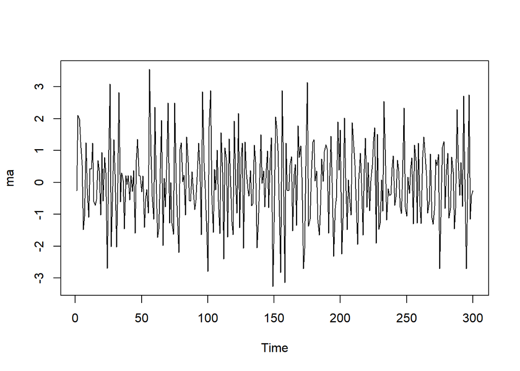

```r
ts.plot(ma)
```

Berdasarkan plot time series, terlihat bahwa data MA(2) yang dibangkitkan stasioner dalam rataan

### 1.3.2 Plot ACF

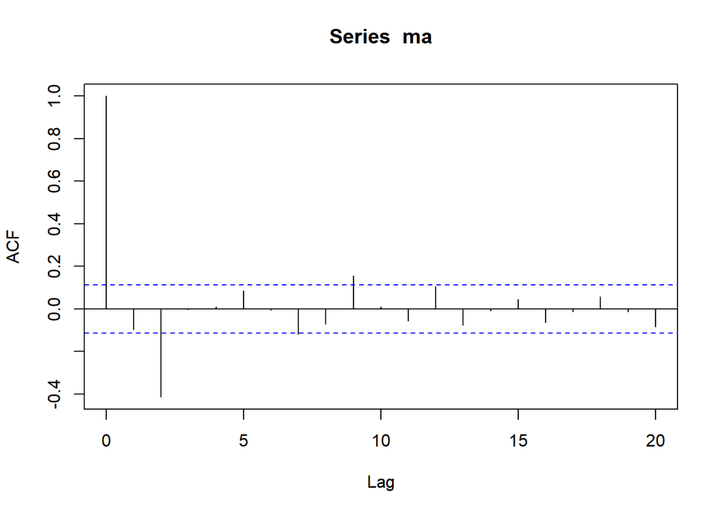

```r
acf(ma,lag.max = 20)
```

Berdasarkan plot AFC tersebut, terlihat bahwa plot ACF *cuts off* di lag kedua, namun pada lag 1 terlihat nilai ACF tidak melebihi batas signifikan sehingga perlu diperiksa lebih lanjut.

### 1.3.3 Plot PACF

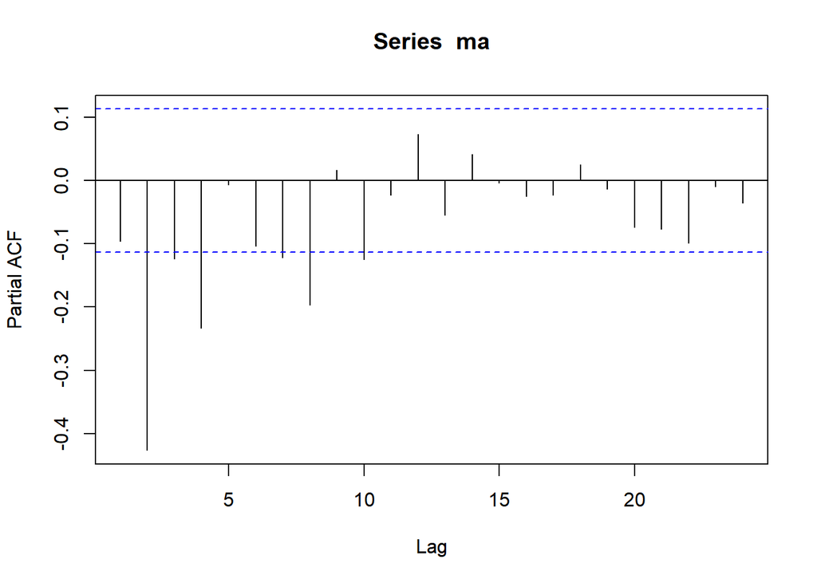

```r
pacf(ma)
```

Berdasarkan plot PACF tersebut, terlihat bahwa plot PACF cenderung *tails off* dan membentuk gelombang lembah karena nilai teta adalah positif

### 1.3.4 Plot EACF

```r
TSA::eacf(ma)
```

```
## AR/MA
##   0 1 2 3 4 5 6 7 8 9 10 11 12 13
## 0 o x o o o o x o x o o  o  o  o
## 1 x x x o o o o o x o o  o  o  o
## 2 x x o o o o o o x o o  o  o  o
## 3 x x x x o o o o o o o  o  o  o
## 4 o x x x x o o o o o o  o  o  o
## 5 x x o x o o x o o o o  o  o  o
## 6 x x o x x x x o o o o  o  o  o
## 7 x o x x x x x x x o o  x  o  o
```

Berdasarkan pola segitiga nol pada plot EACF, terlihat bahwa segitiga nol berada pada ordo AR(0) dan ordo MA(2)

### 1.3.5 Scatterplot Antar Lag

#### 1.3.5.1 Korelasi antara $Y_t$ dengan $Y_{t-1}$

```r
yt_ma <- ma[-1]
yt_ma
```

```
##   [1]  2.1043993204  1.9850308508  1.2714044546  0.5391982470 -1.4764956431
##   [6] -1.0697544570  1.2421959643 -0.1892581100 -1.0950010095  0.4324913816
##  [11]  0.4227821313  1.2357127294 -0.5947763447 -0.7229179572 -0.5411926093
##  [16]  0.6893687965  0.3696135492 -1.0173754345  0.9370708844 -0.5874634877
##  [21]  0.7902427406  0.3171918496 -2.6948611435  0.3254769823  3.0861320795
##  [26] -2.0138902829 -0.6039262951  1.3378505706  0.2634917317 -2.0225862110
##  [31] -0.0288792115  2.8251993098 -0.6130342350  0.2947345464  0.0667703557
##  [36] -1.4572363604  0.2099322735 -0.0621700760  0.2160836386 -0.5467223673
##  [41]  0.2172332299 -0.2843100221  0.3699978168 -1.5891130418  0.7104427598
##  [46]  1.3562292090  0.2204316235  0.2012595408 -0.2985892568  0.2023695742
##  [51] -1.4100858822 -0.5119393782 -0.2225936799 -0.9594105650  3.5443281759
##  [56]  0.8165345916 -0.4341426223 -1.1550194018  2.3645967666  0.0947045043
##  [61] -1.7186650700 -1.4745932758  0.4280521364  1.9547843996 -1.9786722522
##  [66]  0.1295707274 -0.7614444931  0.7986491980  2.4901468693 -1.2748874515
##  [71]  0.0006323193 -1.2803820775 -1.6295508068  2.4893932972 -0.0108359276
```

[output cut: 45 more lines]

```r
yt_1_ma <- ma[-300]
yt_1_ma
```

```
##   [1] -0.2609983009  2.1043993204  1.9850308508  1.2714044546  0.5391982470
##   [6] -1.4764956431 -1.0697544570  1.2421959643 -0.1892581100 -1.0950010095
##  [11]  0.4324913816  0.4227821313  1.2357127294 -0.5947763447 -0.7229179572
##  [16] -0.5411926093  0.6893687965  0.3696135492 -1.0173754345  0.9370708844
##  [21] -0.5874634877  0.7902427406  0.3171918496 -2.6948611435  0.3254769823
##  [26]  3.0861320795 -2.0138902829 -0.6039262951  1.3378505706  0.2634917317
##  [31] -2.0225862110 -0.0288792115  2.8251993098 -0.6130342350  0.2947345464
##  [36]  0.0667703557 -1.4572363604  0.2099322735 -0.0621700760  0.2160836386
##  [41] -0.5467223673  0.2172332299 -0.2843100221  0.3699978168 -1.5891130418
##  [46]  0.7104427598  1.3562292090  0.2204316235  0.2012595408 -0.2985892568
##  [51]  0.2023695742 -1.4100858822 -0.5119393782 -0.2225936799 -0.9594105650
##  [56]  3.5443281759  0.8165345916 -0.4341426223 -1.1550194018  2.3645967666
##  [61]  0.0947045043 -1.7186650700 -1.4745932758  0.4280521364  1.9547843996
##  [66] -1.9786722522  0.1295707274 -0.7614444931  0.7986491980  2.4901468693
##  [71] -1.2748874515  0.0006323193 -1.2803820775 -1.6295508068  2.4893932972
```

[output cut: 45 more lines]

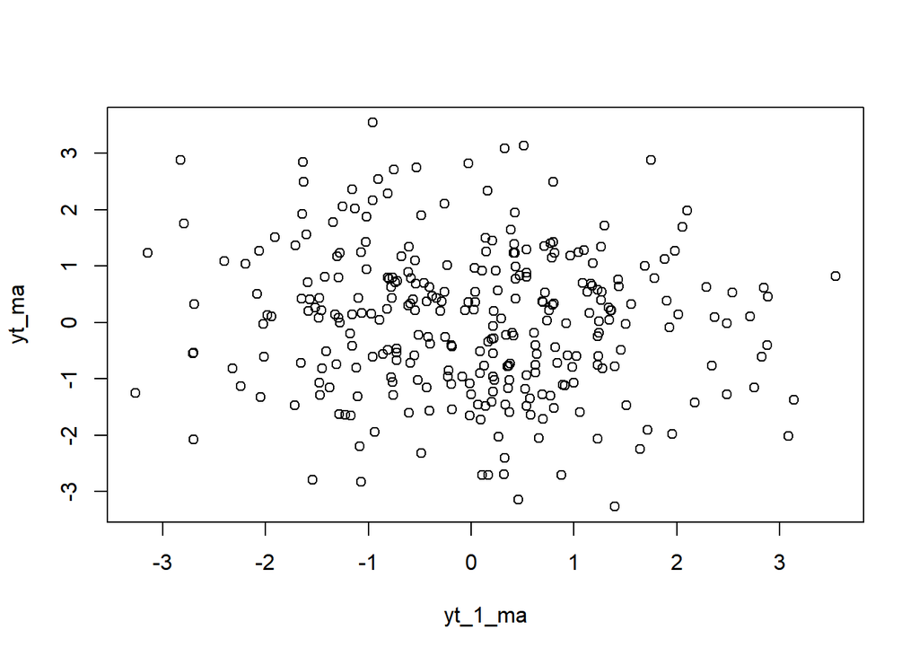

```r
plot(y=yt_ma,x=yt_1_ma)
```

```r
cor(yt_ma,yt_1_ma)
```

```
## [1] -0.09545678
```

#### 1.3.5.2 Korelasi antara $Y_t$ dengan $Y_{t-2}$

```r
yt_ma2 <- ma[-c(1,2)]
yt_ma2
```

```
##   [1]  1.9850308508  1.2714044546  0.5391982470 -1.4764956431 -1.0697544570
##   [6]  1.2421959643 -0.1892581100 -1.0950010095  0.4324913816  0.4227821313
##  [11]  1.2357127294 -0.5947763447 -0.7229179572 -0.5411926093  0.6893687965
##  [16]  0.3696135492 -1.0173754345  0.9370708844 -0.5874634877  0.7902427406
##  [21]  0.3171918496 -2.6948611435  0.3254769823  3.0861320795 -2.0138902829
##  [26] -0.6039262951  1.3378505706  0.2634917317 -2.0225862110 -0.0288792115
##  [31]  2.8251993098 -0.6130342350  0.2947345464  0.0667703557 -1.4572363604
##  [36]  0.2099322735 -0.0621700760  0.2160836386 -0.5467223673  0.2172332299
##  [41] -0.2843100221  0.3699978168 -1.5891130418  0.7104427598  1.3562292090
##  [46]  0.2204316235  0.2012595408 -0.2985892568  0.2023695742 -1.4100858822
##  [51] -0.5119393782 -0.2225936799 -0.9594105650  3.5443281759  0.8165345916
##  [56] -0.4341426223 -1.1550194018  2.3645967666  0.0947045043 -1.7186650700
##  [61] -1.4745932758  0.4280521364  1.9547843996 -1.9786722522  0.1295707274
##  [66] -0.7614444931  0.7986491980  2.4901468693 -1.2748874515  0.0006323193
##  [71] -1.2803820775 -1.6295508068  2.4893932972 -0.0108359276 -1.0866566563
```

[output cut: 45 more lines]

```r
yt_2_ma <- ma[-c(299,300)]
yt_2_ma
```

```
##   [1] -0.2609983009  2.1043993204  1.9850308508  1.2714044546  0.5391982470
##   [6] -1.4764956431 -1.0697544570  1.2421959643 -0.1892581100 -1.0950010095
##  [11]  0.4324913816  0.4227821313  1.2357127294 -0.5947763447 -0.7229179572
##  [16] -0.5411926093  0.6893687965  0.3696135492 -1.0173754345  0.9370708844
##  [21] -0.5874634877  0.7902427406  0.3171918496 -2.6948611435  0.3254769823
##  [26]  3.0861320795 -2.0138902829 -0.6039262951  1.3378505706  0.2634917317
##  [31] -2.0225862110 -0.0288792115  2.8251993098 -0.6130342350  0.2947345464
##  [36]  0.0667703557 -1.4572363604  0.2099322735 -0.0621700760  0.2160836386
##  [41] -0.5467223673  0.2172332299 -0.2843100221  0.3699978168 -1.5891130418
##  [46]  0.7104427598  1.3562292090  0.2204316235  0.2012595408 -0.2985892568
##  [51]  0.2023695742 -1.4100858822 -0.5119393782 -0.2225936799 -0.9594105650
##  [56]  3.5443281759  0.8165345916 -0.4341426223 -1.1550194018  2.3645967666
##  [61]  0.0947045043 -1.7186650700 -1.4745932758  0.4280521364  1.9547843996
##  [66] -1.9786722522  0.1295707274 -0.7614444931  0.7986491980  2.4901468693
##  [71] -1.2748874515  0.0006323193 -1.2803820775 -1.6295508068  2.4893932972
```

[output cut: 45 more lines]

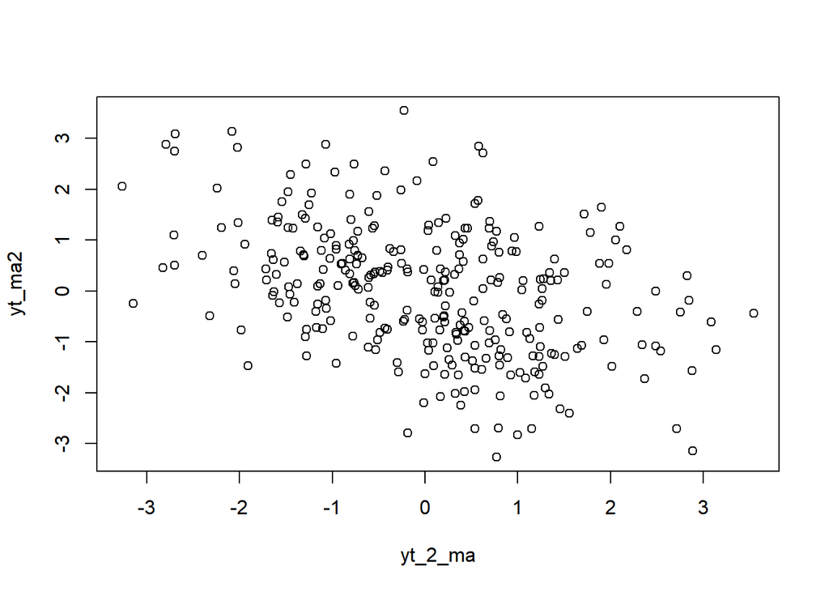

```r
plot(y=yt_ma2,x=yt_2_ma)
```

Berdasarkan scatterplot tersebut, terlihat bahwa terdapat hubungan negatif antara $Y_t$ dengan $Y_{t-2}$.

```r
cor(yt_ma2,yt_2_ma)
```

```
## [1] -0.4153802
```

Korelasi antara $Y_t$ dengan $Y_{t-2}$ dari hasil simulasi tergolong mendekati perhitungan teoritis yaitu

$$\rho_2=\frac{-\theta_2}{1+\theta_1^2+\theta_2^2}=\frac{-0.6}{1+0.4^2+0.6^2}=-0.394$$

#### 1.3.5.3 Korelasi antara $Y_t$ dengan $Y_{t-3}$

```r
yt_ma3 <- ma[-c(1,2,3)]
yt_ma3
```

```
##   [1]  1.2714044546  0.5391982470 -1.4764956431 -1.0697544570  1.2421959643
##   [6] -0.1892581100 -1.0950010095  0.4324913816  0.4227821313  1.2357127294
##  [11] -0.5947763447 -0.7229179572 -0.5411926093  0.6893687965  0.3696135492
##  [16] -1.0173754345  0.9370708844 -0.5874634877  0.7902427406  0.3171918496
##  [21] -2.6948611435  0.3254769823  3.0861320795 -2.0138902829 -0.6039262951
##  [26]  1.3378505706  0.2634917317 -2.0225862110 -0.0288792115  2.8251993098
##  [31] -0.6130342350  0.2947345464  0.0667703557 -1.4572363604  0.2099322735
##  [36] -0.0621700760  0.2160836386 -0.5467223673  0.2172332299 -0.2843100221
##  [41]  0.3699978168 -1.5891130418  0.7104427598  1.3562292090  0.2204316235
##  [46]  0.2012595408 -0.2985892568  0.2023695742 -1.4100858822 -0.5119393782
##  [51] -0.2225936799 -0.9594105650  3.5443281759  0.8165345916 -0.4341426223
##  [56] -1.1550194018  2.3645967666  0.0947045043 -1.7186650700 -1.4745932758
##  [61]  0.4280521364  1.9547843996 -1.9786722522  0.1295707274 -0.7614444931
##  [66]  0.7986491980  2.4901468693 -1.2748874515  0.0006323193 -1.2803820775
##  [71] -1.6295508068  2.4893932972 -0.0108359276 -1.0866566563 -2.1947829707
```

[output cut: 45 more lines]

```r
yt_3_ma <- ma[-c(288, 299,300)]
yt_3_ma
```

```
##   [1] -0.2609983009  2.1043993204  1.9850308508  1.2714044546  0.5391982470
##   [6] -1.4764956431 -1.0697544570  1.2421959643 -0.1892581100 -1.0950010095
##  [11]  0.4324913816  0.4227821313  1.2357127294 -0.5947763447 -0.7229179572
##  [16] -0.5411926093  0.6893687965  0.3696135492 -1.0173754345  0.9370708844
##  [21] -0.5874634877  0.7902427406  0.3171918496 -2.6948611435  0.3254769823
##  [26]  3.0861320795 -2.0138902829 -0.6039262951  1.3378505706  0.2634917317
##  [31] -2.0225862110 -0.0288792115  2.8251993098 -0.6130342350  0.2947345464
##  [36]  0.0667703557 -1.4572363604  0.2099322735 -0.0621700760  0.2160836386
##  [41] -0.5467223673  0.2172332299 -0.2843100221  0.3699978168 -1.5891130418
##  [46]  0.7104427598  1.3562292090  0.2204316235  0.2012595408 -0.2985892568
##  [51]  0.2023695742 -1.4100858822 -0.5119393782 -0.2225936799 -0.9594105650
##  [56]  3.5443281759  0.8165345916 -0.4341426223 -1.1550194018  2.3645967666
##  [61]  0.0947045043 -1.7186650700 -1.4745932758  0.4280521364  1.9547843996
##  [66] -1.9786722522  0.1295707274 -0.7614444931  0.7986491980  2.4901468693
##  [71] -1.2748874515  0.0006323193 -1.2803820775 -1.6295508068  2.4893932972
```

[output cut: 45 more lines]

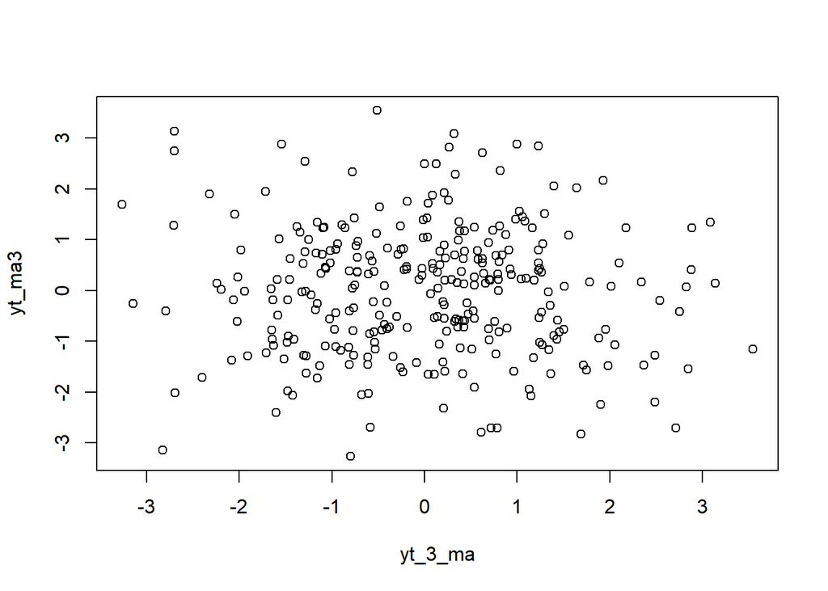

```r
plot(y=yt_ma3,x=yt_3_ma)
```

Berdasarkan scatterplot tersebut, terlihat bahwa $Y_t$ dan $Y_{t-3}$ sudah menunjukkan pola yang tidak beraturan atau bisa disebut tidak berpola.

```r
cor(yt_ma3,yt_3_ma)
```

```
## [1] -0.03728138
```

Korelasi antara $Y_t$ dengan $Y_{t-3}$ dari hasil simulasi mendekati nilai teoritis yang menyatakan bahwa $\rho_k=0$ untuk k>q

# 2 AR(2)

Dalam kasus ini, akan dibangkitkan suatu data dengan model AR(2) sebanyak 300 data yang memiliki nilai $\phi_1 = 0.5$ dan $\phi_2 = 0.2$. Rumusan model tersebut adalah sebagai berikut

$$Y_t = e_t+0.5Y_{t-1}+0.2Y_{t-2}$$

## 2.1 Fungsi Manual

```r
set.seed(1058)
ar <- c(1:300)
ar[1] <- wn[1]
ar[2] <- wn[2] + 0.5 * ar[1]
```

```r
for (i in 3:300) {
  ar[i] <- wn[i] + 0.5 * ar[i-1] + 0.2 * ar[i-2]
}
ar
```

```
##   [1] -0.26099830 -2.15705193 -0.11291486 -0.02527072  1.29970521 -0.02016951
##   [7] -0.28493124  0.48280065 -0.07399647 -0.76122323 -0.44627991 -0.46542115
##  [13]  0.84721015  0.14939326  0.15027569 -0.58239785  0.09694149  0.03239023
##  [19] -0.72678124  0.33545188 -0.74556680  0.59279379  0.36310822 -1.76932631
##  [25] -1.18484540  0.74905906 -1.42187336 -0.77161647 -0.35218926 -0.06602370
##  [31] -1.82948204 -1.48860137  0.45512058 -0.39346052  0.99889879  0.73538930
##  [37] -0.10114619  0.22776800 -0.31718238  0.01746914 -0.79572387 -0.39523962
##  [43] -1.08603639 -0.54429994 -2.48492690 -1.39244883 -1.05077253 -0.55114474
##  [49] -0.09791246 -0.15100989  0.34324090 -1.08843090 -1.21644940 -2.08276704
##  [55] -3.19135570  0.01531030 -0.14707415  0.90532403 -0.05132750  2.91564738
##  [61]  2.36161642  2.06704370  0.70092920  1.05182271  2.25311178  0.16582364
##  [67]  1.14687493 -0.61216407  0.60244010  2.20933320  1.16997385  2.22374115
##  [73]  0.51112984 -0.54499930  1.32015333  0.38922421  0.20150128 -2.21615564
##  [79] -1.13694626 -1.23044468 -0.94680292 -0.66536652 -1.58663008  0.11411283
##  [85]  0.15315536  0.33433119 -0.04858061  0.42718411 -0.00901908 -0.62838227
```

[output cut: 35 more lines]

## 2.2 Fungsi arima.sim()

```r
ar2 <- arima.sim(list(order=c(2,0,0), ar=c(0.5,0.2)), n=300)
ar2
```

[output not shown]

[output cut: 39 more lines]

## 2.3 Karakteristik AR(2)

### 2.3.1 Plot Time Series

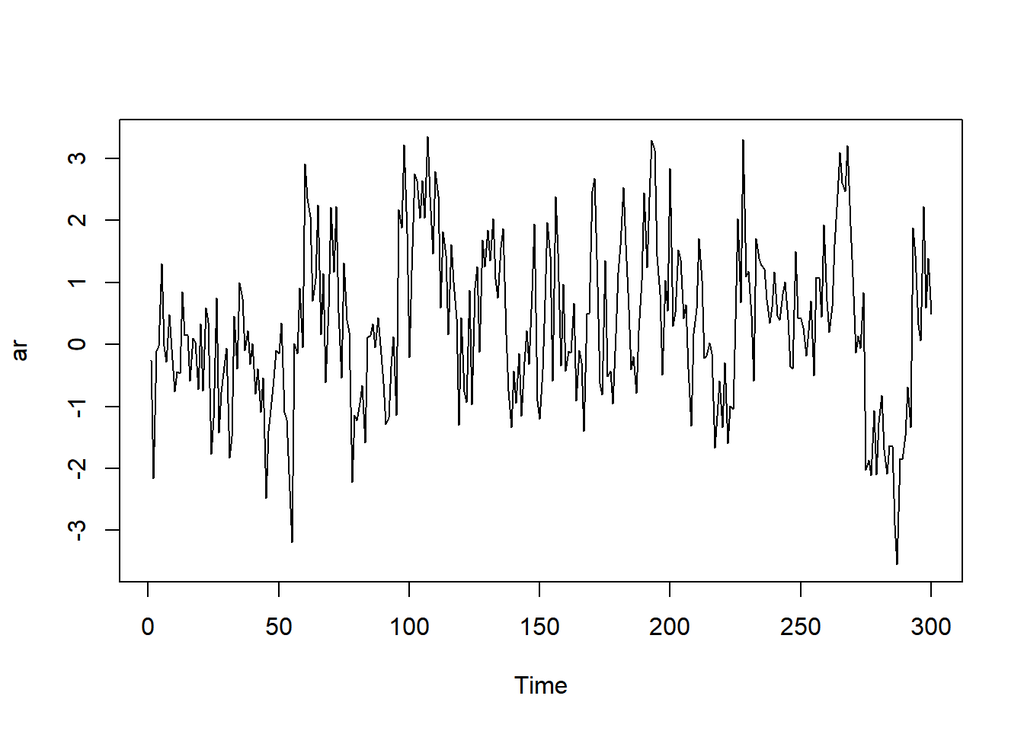

```r
ts.plot(ar)
```

Berdasarkan plot time series tersebut terlihat bahwa data cenderung stasioner pada rataan

### 2.3.2 Plot ACF

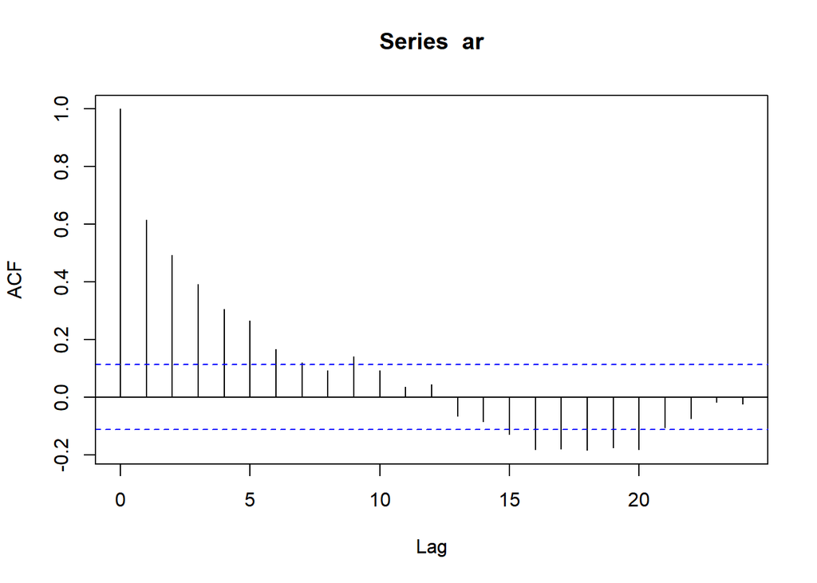

```r
acf(ar)
```

Berdasarkan plot ACF tersebut terlihat bahwa plot ACF cenderung *tails off*

### 2.3.3 Plot PACF

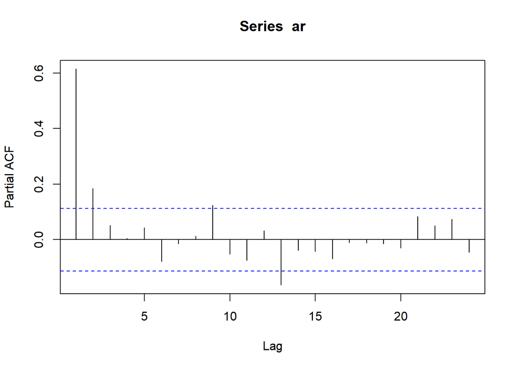

```r
pacf(ar)
```

Berdasarkan plot PACF tersebut, terlihat bahwa plot PACF *cuts off* pada lag kedua

### 2.3.4 Plot EACF

```r
TSA::eacf(ar)
```

```
## AR/MA
##   0 1 2 3 4 5 6 7 8 9 10 11 12 13
## 0 x x x x x x x o x o o  o  o  o
## 1 x o o o x o o o x o o  o  o  o
## 2 x o o o o o o o x o o  o  o  o
## 3 o o o o o o o o o o o  o  o  o
## 4 x x o o o o o o o o o  o  o  o
## 5 x x x o o o o o o o o  o  o  o
## 6 x x x o o o o o o o o  o  o  o
## 7 x o x o o o o o o o o  o  o  o
```

### 2.3.5 Scatterplot Antar Lag

#### 2.3.5.1 Korelasi antara $Y_t$ dengan $Y_{t-1}$

```r
yt_ar <- ar[-1]
yt_ar
```

```
##   [1] -2.15705193 -0.11291486 -0.02527072  1.29970521 -0.02016951 -0.28493124
##   [7]  0.48280065 -0.07399647 -0.76122323 -0.44627991 -0.46542115  0.84721015
##  [13]  0.14939326  0.15027569 -0.58239785  0.09694149  0.03239023 -0.72678124
##  [19]  0.33545188 -0.74556680  0.59279379  0.36310822 -1.76932631 -1.18484540
##  [25]  0.74905906 -1.42187336 -0.77161647 -0.35218926 -0.06602370 -1.82948204
##  [31] -1.48860137  0.45512058 -0.39346052  0.99889879  0.73538930 -0.10114619
##  [37]  0.22776800 -0.31718238  0.01746914 -0.79572387 -0.39523962 -1.08603639
##  [43] -0.54429994 -2.48492690 -1.39244883 -1.05077253 -0.55114474 -0.09791246
##  [49] -0.15100989  0.34324090 -1.08843090 -1.21644940 -2.08276704 -3.19135570
##  [55]  0.01531030 -0.14707415  0.90532403 -0.05132750  2.91564738  2.36161642
##  [61]  2.06704370  0.70092920  1.05182271  2.25311178  0.16582364  1.14687493
##  [67] -0.61216407  0.60244010  2.20933320  1.16997385  2.22374115  0.51112984
##  [73] -0.54499930  1.32015333  0.38922421  0.20150128 -2.21615564 -1.13694626
##  [79] -1.23044468 -0.94680292 -0.66536652 -1.58663008  0.11411283  0.15315536
##  [85]  0.33433119 -0.04858061  0.42718411 -0.00901908 -0.62838227 -1.29216595
```

[output cut: 35 more lines]

```r
yt_1_ar <- ar[-300]
yt_1_ar
```

```
##   [1] -0.26099830 -2.15705193 -0.11291486 -0.02527072  1.29970521 -0.02016951
##   [7] -0.28493124  0.48280065 -0.07399647 -0.76122323 -0.44627991 -0.46542115
##  [13]  0.84721015  0.14939326  0.15027569 -0.58239785  0.09694149  0.03239023
##  [19] -0.72678124  0.33545188 -0.74556680  0.59279379  0.36310822 -1.76932631
##  [25] -1.18484540  0.74905906 -1.42187336 -0.77161647 -0.35218926 -0.06602370
##  [31] -1.82948204 -1.48860137  0.45512058 -0.39346052  0.99889879  0.73538930
##  [37] -0.10114619  0.22776800 -0.31718238  0.01746914 -0.79572387 -0.39523962
##  [43] -1.08603639 -0.54429994 -2.48492690 -1.39244883 -1.05077253 -0.55114474
##  [49] -0.09791246 -0.15100989  0.34324090 -1.08843090 -1.21644940 -2.08276704
##  [55] -3.19135570  0.01531030 -0.14707415  0.90532403 -0.05132750  2.91564738
##  [61]  2.36161642  2.06704370  0.70092920  1.05182271  2.25311178  0.16582364
##  [67]  1.14687493 -0.61216407  0.60244010  2.20933320  1.16997385  2.22374115
##  [73]  0.51112984 -0.54499930  1.32015333  0.38922421  0.20150128 -2.21615564
##  [79] -1.13694626 -1.23044468 -0.94680292 -0.66536652 -1.58663008  0.11411283
##  [85]  0.15315536  0.33433119 -0.04858061  0.42718411 -0.00901908 -0.62838227
```

[output cut: 35 more lines]

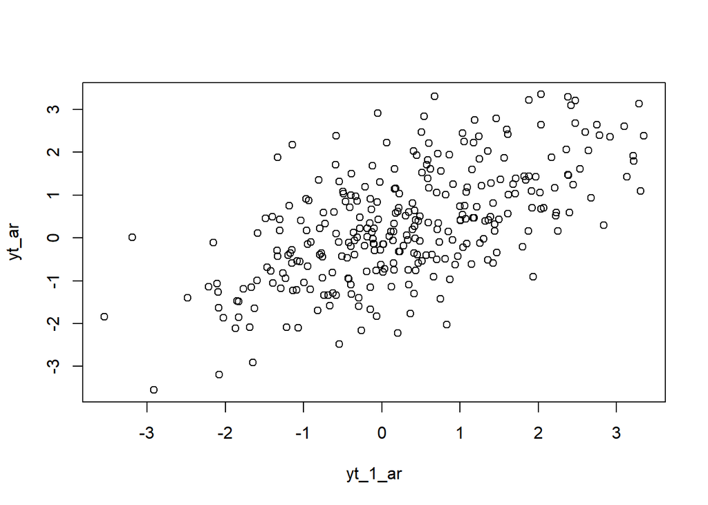

```r
plot(y=yt_ar,x=yt_1_ar)
```

Berdasarkan scatterplot tersebut, terlihat bahwa terdapat hubungan positif antara $Y_t$ dengan $Y_{t-1}$.

```r
cor(yt_ar,yt_1_ar)
```

```
## [1] 0.6146575
```

Korelasi antara $Y_t$ dengan $Y_{t-1}$ dari hasil simulasi mendekati perhitungan teoritis yaitu

$$\rho_1=\frac{\phi_1}{1-\phi_2}=\frac{0.5}{1-0.2}=0.625$$

#### 2.3.5.2 Korelasi antara $Y_t$ dengan $Y_{t-2}$

```r
yt_ar2 <- ar[-c(1,2)]
yt_ar2
```

```
##   [1] -0.11291486 -0.02527072  1.29970521 -0.02016951 -0.28493124  0.48280065
##   [7] -0.07399647 -0.76122323 -0.44627991 -0.46542115  0.84721015  0.14939326
##  [13]  0.15027569 -0.58239785  0.09694149  0.03239023 -0.72678124  0.33545188
##  [19] -0.74556680  0.59279379  0.36310822 -1.76932631 -1.18484540  0.74905906
##  [25] -1.42187336 -0.77161647 -0.35218926 -0.06602370 -1.82948204 -1.48860137
##  [31]  0.45512058 -0.39346052  0.99889879  0.73538930 -0.10114619  0.22776800
##  [37] -0.31718238  0.01746914 -0.79572387 -0.39523962 -1.08603639 -0.54429994
##  [43] -2.48492690 -1.39244883 -1.05077253 -0.55114474 -0.09791246 -0.15100989
##  [49]  0.34324090 -1.08843090 -1.21644940 -2.08276704 -3.19135570  0.01531030
##  [55] -0.14707415  0.90532403 -0.05132750  2.91564738  2.36161642  2.06704370
##  [61]  0.70092920  1.05182271  2.25311178  0.16582364  1.14687493 -0.61216407
##  [67]  0.60244010  2.20933320  1.16997385  2.22374115  0.51112984 -0.54499930
##  [73]  1.32015333  0.38922421  0.20150128 -2.21615564 -1.13694626 -1.23044468
##  [79] -0.94680292 -0.66536652 -1.58663008  0.11411283  0.15315536  0.33433119
##  [85] -0.04858061  0.42718411 -0.00901908 -0.62838227 -1.29216595 -1.17322109
```

[output cut: 35 more lines]

```r
yt_2_ar <- ar[-c(299,300)]
yt_2_ar
```

```
##   [1] -0.26099830 -2.15705193 -0.11291486 -0.02527072  1.29970521 -0.02016951
##   [7] -0.28493124  0.48280065 -0.07399647 -0.76122323 -0.44627991 -0.46542115
##  [13]  0.84721015  0.14939326  0.15027569 -0.58239785  0.09694149  0.03239023
##  [19] -0.72678124  0.33545188 -0.74556680  0.59279379  0.36310822 -1.76932631
##  [25] -1.18484540  0.74905906 -1.42187336 -0.77161647 -0.35218926 -0.06602370
##  [31] -1.82948204 -1.48860137  0.45512058 -0.39346052  0.99889879  0.73538930
##  [37] -0.10114619  0.22776800 -0.31718238  0.01746914 -0.79572387 -0.39523962
##  [43] -1.08603639 -0.54429994 -2.48492690 -1.39244883 -1.05077253 -0.55114474
##  [49] -0.09791246 -0.15100989  0.34324090 -1.08843090 -1.21644940 -2.08276704
##  [55] -3.19135570  0.01531030 -0.14707415  0.90532403 -0.05132750  2.91564738
##  [61]  2.36161642  2.06704370  0.70092920  1.05182271  2.25311178  0.16582364
##  [67]  1.14687493 -0.61216407  0.60244010  2.20933320  1.16997385  2.22374115
##  [73]  0.51112984 -0.54499930  1.32015333  0.38922421  0.20150128 -2.21615564
##  [79] -1.13694626 -1.23044468 -0.94680292 -0.66536652 -1.58663008  0.11411283
##  [85]  0.15315536  0.33433119 -0.04858061  0.42718411 -0.00901908 -0.62838227
```

[output cut: 35 more lines]

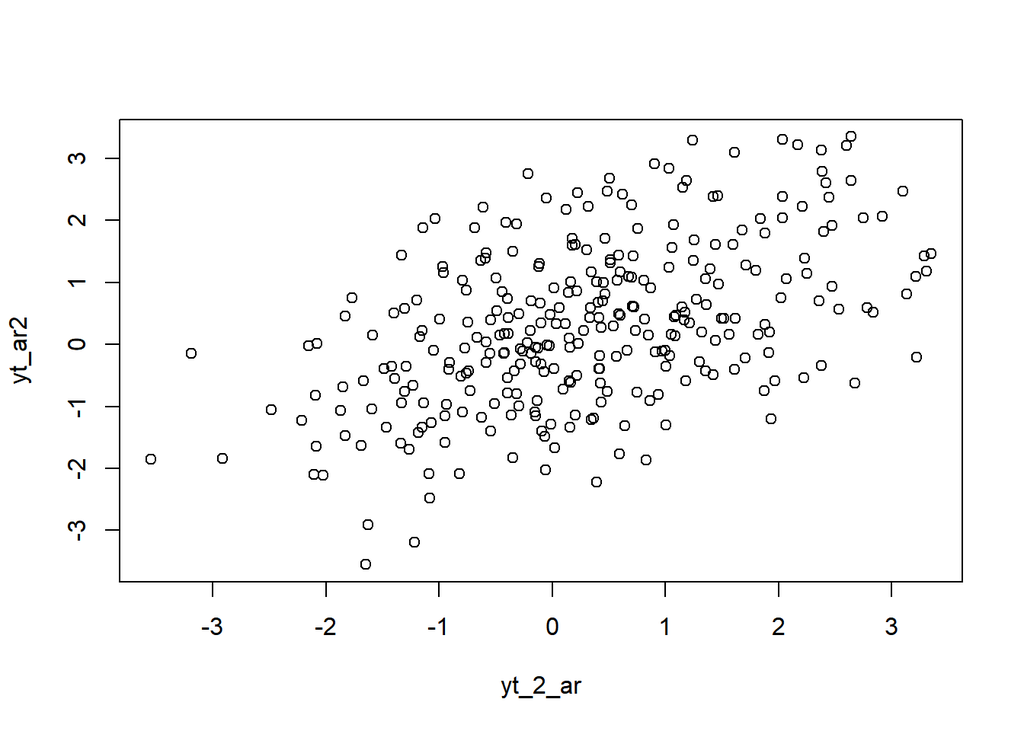

```r
plot(y=yt_ar2,x=yt_2_ar)
```

Berdasarkan scatterplot tersebut, terlihat bahwa terdapat hubungan positif antara $Y_t$ dengan $Y_{t-2}$.

```r
cor(yt_ar2,yt_2_ar)
```

```
## [1] 0.4964749
```

Korelasi antara $Y_t$ dengan $Y_{t-2}$ dari hasil simulasi mendekati perhitungan teoritis yaitu

$$\rho_2=\phi_1\rho_{k-1}+\phi_2\rho_{k-2}=\frac{\phi_2(1-\phi_2)+\phi_1^2}{1-\phi_2}=\frac{0.2(1-0.2)+0.5^2}{1-0.2}=0.5125$$

#### 2.3.5.3 Korelasi antara $Y_t$ dengan $Y_{t-3}$

```r
yt_ar3 <- ar[-c(1,2,3)]
yt_ar3
```

```
##   [1] -0.02527072  1.29970521 -0.02016951 -0.28493124  0.48280065 -0.07399647
##   [7] -0.76122323 -0.44627991 -0.46542115  0.84721015  0.14939326  0.15027569
##  [13] -0.58239785  0.09694149  0.03239023 -0.72678124  0.33545188 -0.74556680
##  [19]  0.59279379  0.36310822 -1.76932631 -1.18484540  0.74905906 -1.42187336
##  [25] -0.77161647 -0.35218926 -0.06602370 -1.82948204 -1.48860137  0.45512058
##  [31] -0.39346052  0.99889879  0.73538930 -0.10114619  0.22776800 -0.31718238
##  [37]  0.01746914 -0.79572387 -0.39523962 -1.08603639 -0.54429994 -2.48492690
##  [43] -1.39244883 -1.05077253 -0.55114474 -0.09791246 -0.15100989  0.34324090
##  [49] -1.08843090 -1.21644940 -2.08276704 -3.19135570  0.01531030 -0.14707415
##  [55]  0.90532403 -0.05132750  2.91564738  2.36161642  2.06704370  0.70092920
##  [61]  1.05182271  2.25311178  0.16582364  1.14687493 -0.61216407  0.60244010
##  [67]  2.20933320  1.16997385  2.22374115  0.51112984 -0.54499930  1.32015333
##  [73]  0.38922421  0.20150128 -2.21615564 -1.13694626 -1.23044468 -0.94680292
##  [79] -0.66536652 -1.58663008  0.11411283  0.15315536  0.33433119 -0.04858061
##  [85]  0.42718411 -0.00901908 -0.62838227 -1.29216595 -1.17322109 -0.35926640
```

[output cut: 35 more lines]

```r
yt_3_ar <- ar[-c(298,299,300)]
yt_3_ar
```

```
##   [1] -0.26099830 -2.15705193 -0.11291486 -0.02527072  1.29970521 -0.02016951
##   [7] -0.28493124  0.48280065 -0.07399647 -0.76122323 -0.44627991 -0.46542115
##  [13]  0.84721015  0.14939326  0.15027569 -0.58239785  0.09694149  0.03239023
##  [19] -0.72678124  0.33545188 -0.74556680  0.59279379  0.36310822 -1.76932631
##  [25] -1.18484540  0.74905906 -1.42187336 -0.77161647 -0.35218926 -0.06602370
##  [31] -1.82948204 -1.48860137  0.45512058 -0.39346052  0.99889879  0.73538930
##  [37] -0.10114619  0.22776800 -0.31718238  0.01746914 -0.79572387 -0.39523962
##  [43] -1.08603639 -0.54429994 -2.48492690 -1.39244883 -1.05077253 -0.55114474
##  [49] -0.09791246 -0.15100989  0.34324090 -1.08843090 -1.21644940 -2.08276704
##  [55] -3.19135570  0.01531030 -0.14707415  0.90532403 -0.05132750  2.91564738
##  [61]  2.36161642  2.06704370  0.70092920  1.05182271  2.25311178  0.16582364
##  [67]  1.14687493 -0.61216407  0.60244010  2.20933320  1.16997385  2.22374115
##  [73]  0.51112984 -0.54499930  1.32015333  0.38922421  0.20150128 -2.21615564
##  [79] -1.13694626 -1.23044468 -0.94680292 -0.66536652 -1.58663008  0.11411283
##  [85]  0.15315536  0.33433119 -0.04858061  0.42718411 -0.00901908 -0.62838227
```

[output cut: 35 more lines]

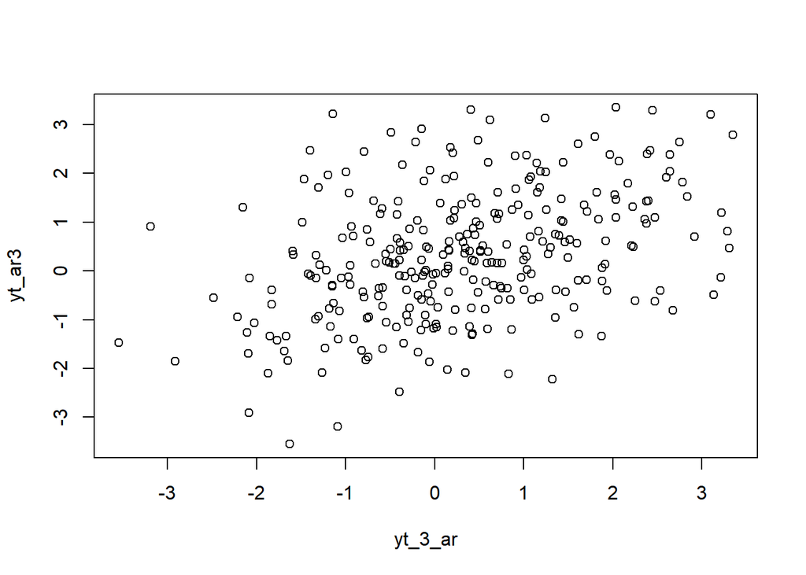

```r
plot(y=yt_ar3,x=yt_3_ar)
```

Berdasarkan scatterplot tersebut, terlihat bahwa terdapat hubungan positif antara $Y_t$ dengan $Y_{t-3}$.

```r
cor(yt_ar3,yt_3_ar)
```

```
## [1] 0.3944373
```

Korelasi antara $Y_t$ dengan $Y_{t-3}$ dari hasil simulasi mendekati perhitungan teoritis yaitu

$$\rho_3=\phi_1\rho_{k-1}+\phi_2\rho_{k-2}=\phi_1\rho_2+\phi_2\rho_1=0.5\times0.5125+0.2\times0.625=0.38125$$

# 3 ARMA(2,2)

Dalam kasus ini, akan dibangkitkan suatu data dengan model ARMA(2,2) sebanyak 300 data yang memiliki nilai $\theta_1 = 0.4$ dan $\theta_2 = 0.6$ serta $\phi_1 = 0.5$ dan $\phi_2 = 0.2$. Rumusan model tersebut adalah sebagai berikut

$$Y_t =
0.5Y_{t-1}+0.2Y_{t-2}+e_t-0.4_{t-1}-0.6_{t-2}$$

## 3.1 Fungsi Manual

```r
set.seed(1058)
theta1 = 0.4
theta2 = 0.6
phi1 = 0.5
phi2 = 0.2

y.arma=c(1:300)
for (i in 3:300){y.arma[i] = phi1*y.arma[i-1] + phi2*y.arma[i-2] +
                 wn[i] - theta1*wn[i-1] - theta2*wn[i-2]}
y.arma
```

```
##   [1]  1.000000000  2.000000000  3.185030851  3.263919880  2.808164357
##   [6]  0.580370511 -0.217936330  1.249301902  0.391805575 -0.649237842
##  [11]  0.186233576  0.386051351  1.465985120  0.215426485 -0.322007690
##  [16] -0.659111157  0.295411680  0.385497158 -0.765544520  0.631398056
##  [21] -0.424873364  0.704085670  0.584260012 -2.261914004 -0.688628017
##  [26]  2.289435270 -1.006898251 -0.649488367  0.811726737  0.539457427
##  [31] -1.590512150 -0.716243801  2.148974979  0.318204494  0.883631789
##  [36]  0.572227149 -0.994396428 -0.172820511 -0.347459617  0.007789728
##  [41] -0.612319427 -0.087368538 -0.450458176  0.127295021 -1.615557167
##  [46] -0.071876819  0.997179366  0.704645943  0.753018385  0.218849124
##  [51]  0.462397813 -1.135117151 -0.987018391 -0.943126305 -1.628377396
##  [56]  2.541514217  1.761616221  0.954968331 -0.325211992  2.392984437
##  [61]  1.226154324 -0.626991020 -1.542857921 -0.468775028  1.411825301
##  [66] -1.366514607 -0.271321516 -1.170408173  0.159180808  2.335655639
##  [71] -0.075223470  0.430151712 -1.080350916 -2.083695922  1.231475153
```

[output cut: 45 more lines]

## 3.2 Fungsi arima.sim()

```r
arma22 <- arima.sim(list(order=c(2,0,2), ar = c(0.5,0.2), ma = c(0.4,0.6)), n=300)
arma22
```

```
## Time Series:
## Start = 1
## End = 300
## Frequency = 1
##   [1] -0.889434564 -1.512819533 -0.668999959 -2.066542342 -2.259503170
##   [6] -1.237624032 -1.104279483  1.114810770  0.899043149  0.792478893
##  [11]  0.628642281 -0.286687283  0.027314629 -0.979001695 -0.703014188
##  [16] -1.721541022 -1.215838798 -3.354253865 -2.712988233 -3.098699575
##  [21] -1.806916470 -0.948828860 -0.520857896  0.224092381 -1.041738258
##  [26] -1.445875526 -3.222404046 -4.754331169 -2.510891447 -2.055762880
##  [31]  0.855680990  0.222557957  3.438311056  3.497079064  4.761078840
##  [36]  2.944716637  2.572420690  3.094398445  1.698162022  2.565071494
##  [41] -0.053919888  1.045699453  2.083010817  2.415171200  4.017330625
##  [46]  2.102610618  0.993697331  1.408831514  0.590285959  1.149282963
##  [51] -1.902020603 -1.902507751 -3.014916569 -2.121148552 -1.782354492
```

[output cut: 49 more lines]

## 3.3 Karakteristik ARMA(2,2)

### 3.3.1 Plot Time Series

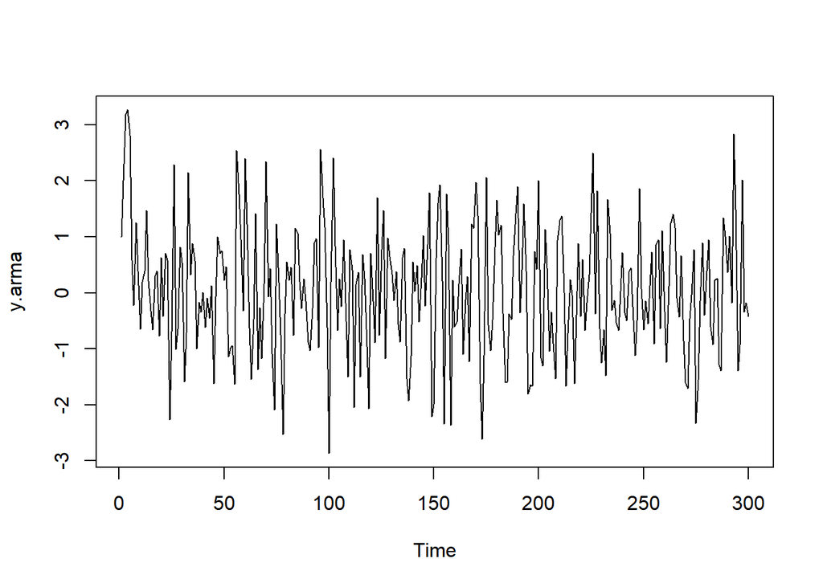

```r
ts.plot(y.arma)
```

Berdasarkan plot time series tersebut, terlihat bahwa model ARMA(2,2) cenderung stasioner dalam rataan

### 3.3.2 Plot ACF

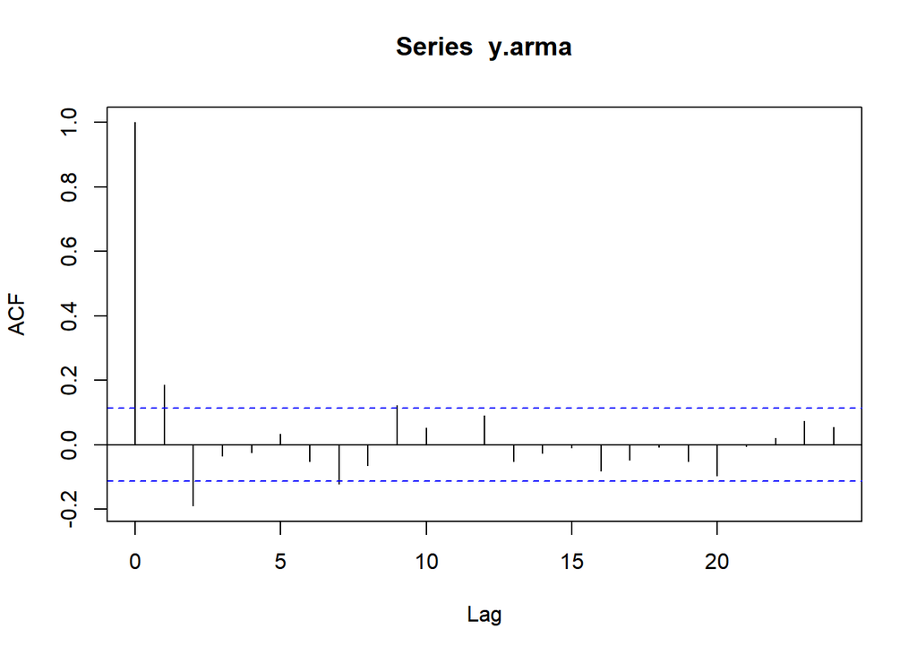

```r
acf(y.arma)
```

### 3.3.3 Plot PACF

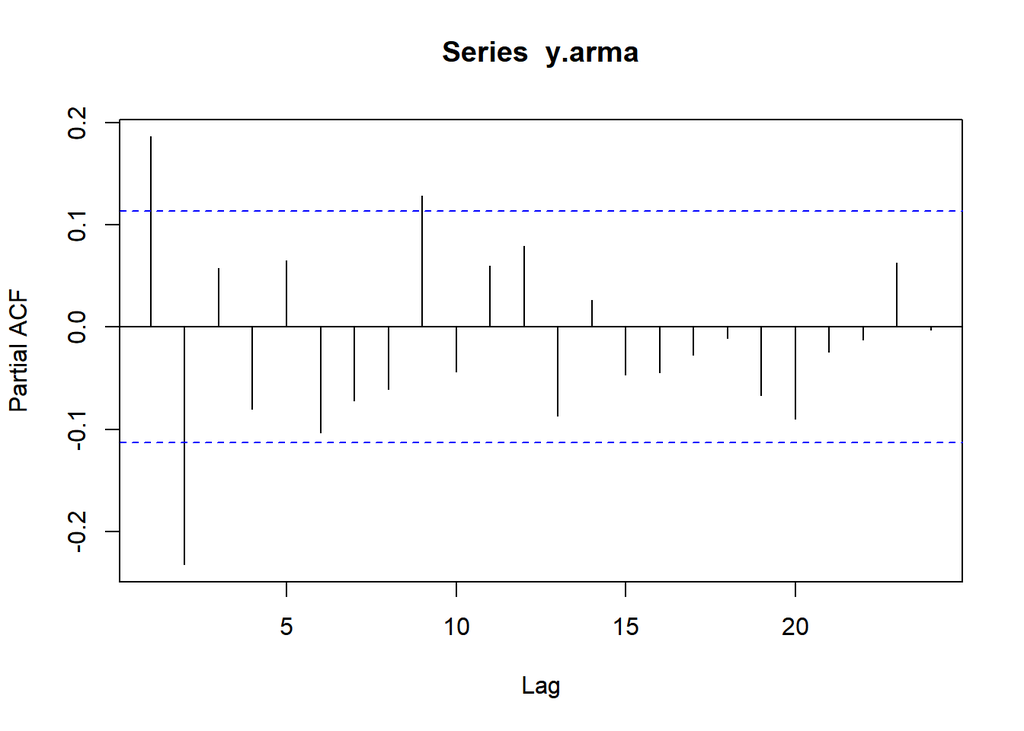

```r
pacf(y.arma)
```

### 3.3.4 Plot EACF

```r
TSA::eacf(y.arma)
```

```
## AR/MA
##   0 1 2 3 4 5 6 7 8 9 10 11 12 13
## 0 x x o o o o x o x o o  o  o  o
## 1 x x o o o o o o x o o  o  o  o
## 2 x x o o o o o o x o o  o  o  o
## 3 x x o o o o o o o o o  o  o  o
## 4 x x o x o o o o o o o  o  o  o
## 5 x x x x o o o o o o o  o  o  o
## 6 x o x x x o x x o o o  o  o  o
## 7 x o x x x x x x o o o  o  o  o
```

### 3.3.5 Scatterplot Antar Lag

#### 3.3.5.1 Korelasi antara $Y_t$ dengan $Y_{t-1}$

```r
yt_arma <- y.arma[-1]
yt_arma
```

```
##   [1]  2.000000000  3.185030851  3.263919880  2.808164357  0.580370511
##   [6] -0.217936330  1.249301902  0.391805575 -0.649237842  0.186233576
##  [11]  0.386051351  1.465985120  0.215426485 -0.322007690 -0.659111157
##  [16]  0.295411680  0.385497158 -0.765544520  0.631398056 -0.424873364
##  [21]  0.704085670  0.584260012 -2.261914004 -0.688628017  2.289435270
##  [26] -1.006898251 -0.649488367  0.811726737  0.539457427 -1.590512150
##  [31] -0.716243801  2.148974979  0.318204494  0.883631789  0.572227149
##  [36] -0.994396428 -0.172820511 -0.347459617  0.007789728 -0.612319427
##  [41] -0.087368538 -0.450458176  0.127295021 -1.615557167 -0.071876819
##  [46]  0.997179366  0.704645943  0.753018385  0.218849124  0.462397813
##  [51] -1.135117151 -0.987018391 -0.943126305 -1.628377396  2.541514217
##  [56]  1.761616221  0.954968331 -0.325211992  2.392984437  1.226154324
##  [61] -0.626991020 -1.542857921 -0.468775028  1.411825301 -1.366514607
##  [66] -0.271321516 -1.170408173  0.159180808  2.335655639 -0.075223470
##  [71]  0.430151712 -1.080350916 -2.083695922  1.231475153  0.188162464
```

[output cut: 45 more lines]

```r
yt_1_arma <- y.arma[-300]
yt_1_arma
```

```
##   [1]  1.000000000  2.000000000  3.185030851  3.263919880  2.808164357
##   [6]  0.580370511 -0.217936330  1.249301902  0.391805575 -0.649237842
##  [11]  0.186233576  0.386051351  1.465985120  0.215426485 -0.322007690
##  [16] -0.659111157  0.295411680  0.385497158 -0.765544520  0.631398056
##  [21] -0.424873364  0.704085670  0.584260012 -2.261914004 -0.688628017
##  [26]  2.289435270 -1.006898251 -0.649488367  0.811726737  0.539457427
##  [31] -1.590512150 -0.716243801  2.148974979  0.318204494  0.883631789
##  [36]  0.572227149 -0.994396428 -0.172820511 -0.347459617  0.007789728
##  [41] -0.612319427 -0.087368538 -0.450458176  0.127295021 -1.615557167
##  [46] -0.071876819  0.997179366  0.704645943  0.753018385  0.218849124
##  [51]  0.462397813 -1.135117151 -0.987018391 -0.943126305 -1.628377396
##  [56]  2.541514217  1.761616221  0.954968331 -0.325211992  2.392984437
##  [61]  1.226154324 -0.626991020 -1.542857921 -0.468775028  1.411825301
##  [66] -1.366514607 -0.271321516 -1.170408173  0.159180808  2.335655639
##  [71] -0.075223470  0.430151712 -1.080350916 -2.083695922  1.231475153
```

[output cut: 45 more lines]

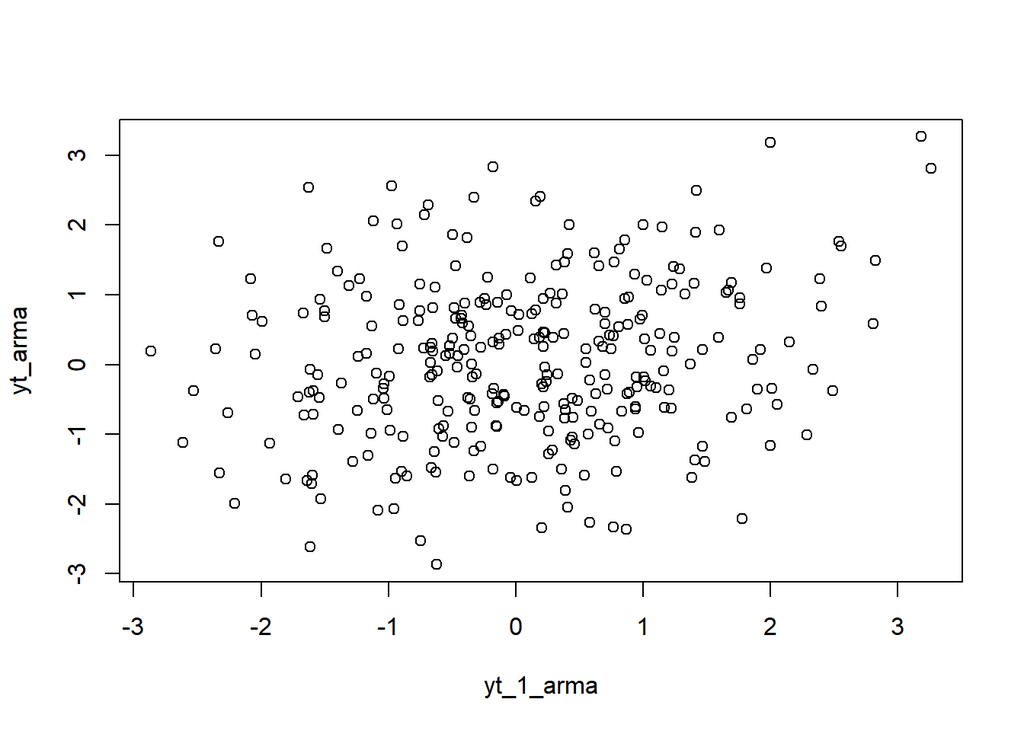

```r
plot(y=yt_arma,x=yt_1_arma)
```

Berdasarkan scatterplot tersebut, terlihat bahwa terdapat hubungan positif antara $Y_t$ dengan $Y_{t-1}$.

```r
cor(yt_arma,yt_1_arma)
```

```
## [1] 0.1862196
```

#### 3.3.5.2 Korelasi antara $Y_t$ dengan $Y_{t-2}$

```r
yt_arma <- y.arma[-c(1,2)]
yt_arma
```

```
##   [1]  3.185030851  3.263919880  2.808164357  0.580370511 -0.217936330
##   [6]  1.249301902  0.391805575 -0.649237842  0.186233576  0.386051351
##  [11]  1.465985120  0.215426485 -0.322007690 -0.659111157  0.295411680
##  [16]  0.385497158 -0.765544520  0.631398056 -0.424873364  0.704085670
##  [21]  0.584260012 -2.261914004 -0.688628017  2.289435270 -1.006898251
##  [26] -0.649488367  0.811726737  0.539457427 -1.590512150 -0.716243801
##  [31]  2.148974979  0.318204494  0.883631789  0.572227149 -0.994396428
##  [36] -0.172820511 -0.347459617  0.007789728 -0.612319427 -0.087368538
##  [41] -0.450458176  0.127295021 -1.615557167 -0.071876819  0.997179366
##  [46]  0.704645943  0.753018385  0.218849124  0.462397813 -1.135117151
##  [51] -0.987018391 -0.943126305 -1.628377396  2.541514217  1.761616221
##  [56]  0.954968331 -0.325211992  2.392984437  1.226154324 -0.626991020
##  [61] -1.542857921 -0.468775028  1.411825301 -1.366514607 -0.271321516
##  [66] -1.170408173  0.159180808  2.335655639 -0.075223470  0.430151712
##  [71] -1.080350916 -2.083695922  1.231475153  0.188162464 -0.746280394
```

[output cut: 45 more lines]

```r
yt_2_arma <- y.arma[-c(299,300)]
yt_2_arma
```

```
##   [1]  1.000000000  2.000000000  3.185030851  3.263919880  2.808164357
##   [6]  0.580370511 -0.217936330  1.249301902  0.391805575 -0.649237842
##  [11]  0.186233576  0.386051351  1.465985120  0.215426485 -0.322007690
##  [16] -0.659111157  0.295411680  0.385497158 -0.765544520  0.631398056
##  [21] -0.424873364  0.704085670  0.584260012 -2.261914004 -0.688628017
##  [26]  2.289435270 -1.006898251 -0.649488367  0.811726737  0.539457427
##  [31] -1.590512150 -0.716243801  2.148974979  0.318204494  0.883631789
##  [36]  0.572227149 -0.994396428 -0.172820511 -0.347459617  0.007789728
##  [41] -0.612319427 -0.087368538 -0.450458176  0.127295021 -1.615557167
##  [46] -0.071876819  0.997179366  0.704645943  0.753018385  0.218849124
##  [51]  0.462397813 -1.135117151 -0.987018391 -0.943126305 -1.628377396
##  [56]  2.541514217  1.761616221  0.954968331 -0.325211992  2.392984437
##  [61]  1.226154324 -0.626991020 -1.542857921 -0.468775028  1.411825301
##  [66] -1.366514607 -0.271321516 -1.170408173  0.159180808  2.335655639
##  [71] -0.075223470  0.430151712 -1.080350916 -2.083695922  1.231475153
```

[output cut: 45 more lines]

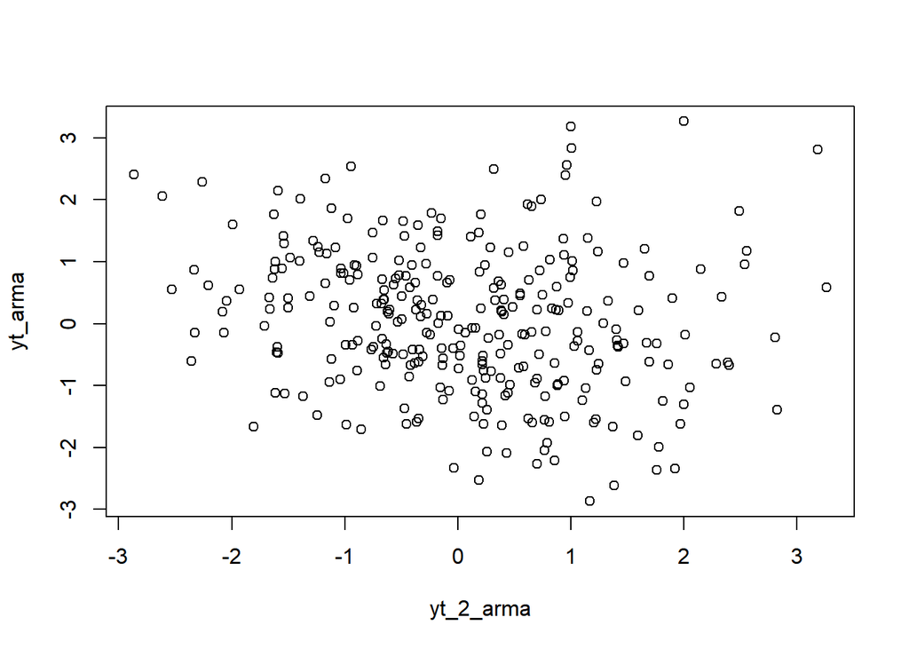

```r
plot(y=yt_arma,x=yt_2_arma)
```

Berdasarkan scatterplot tersebut, terlihat bahwa terdapat hubungan negatif antara $Y_t$ dengan $Y_{t-2}$.

```r
cor(yt_arma,yt_2_arma)
```

```
## [1] -0.1908316
```

#### 3.3.5.3 Korelasi antara $Y_t$ dengan $Y_{t-3}$

```r
yt_arma <- y.arma[-c(1,2,3)]
yt_arma
```

```
##   [1]  3.263919880  2.808164357  0.580370511 -0.217936330  1.249301902
##   [6]  0.391805575 -0.649237842  0.186233576  0.386051351  1.465985120
##  [11]  0.215426485 -0.322007690 -0.659111157  0.295411680  0.385497158
##  [16] -0.765544520  0.631398056 -0.424873364  0.704085670  0.584260012
##  [21] -2.261914004 -0.688628017  2.289435270 -1.006898251 -0.649488367
##  [26]  0.811726737  0.539457427 -1.590512150 -0.716243801  2.148974979
##  [31]  0.318204494  0.883631789  0.572227149 -0.994396428 -0.172820511
##  [36] -0.347459617  0.007789728 -0.612319427 -0.087368538 -0.450458176
##  [41]  0.127295021 -1.615557167 -0.071876819  0.997179366  0.704645943
##  [46]  0.753018385  0.218849124  0.462397813 -1.135117151 -0.987018391
##  [51] -0.943126305 -1.628377396  2.541514217  1.761616221  0.954968331
##  [56] -0.325211992  2.392984437  1.226154324 -0.626991020 -1.542857921
##  [61] -0.468775028  1.411825301 -1.366514607 -0.271321516 -1.170408173
##  [66]  0.159180808  2.335655639 -0.075223470  0.430151712 -1.080350916
##  [71] -2.083695922  1.231475153  0.188162464 -0.746280394 -2.530290675
```

[output cut: 45 more lines]

```r
yt_3_arma <- y.arma[-c(298,299,300)]
yt_3_arma
```

```
##   [1]  1.000000000  2.000000000  3.185030851  3.263919880  2.808164357
##   [6]  0.580370511 -0.217936330  1.249301902  0.391805575 -0.649237842
##  [11]  0.186233576  0.386051351  1.465985120  0.215426485 -0.322007690
##  [16] -0.659111157  0.295411680  0.385497158 -0.765544520  0.631398056
##  [21] -0.424873364  0.704085670  0.584260012 -2.261914004 -0.688628017
##  [26]  2.289435270 -1.006898251 -0.649488367  0.811726737  0.539457427
##  [31] -1.590512150 -0.716243801  2.148974979  0.318204494  0.883631789
##  [36]  0.572227149 -0.994396428 -0.172820511 -0.347459617  0.007789728
##  [41] -0.612319427 -0.087368538 -0.450458176  0.127295021 -1.615557167
##  [46] -0.071876819  0.997179366  0.704645943  0.753018385  0.218849124
##  [51]  0.462397813 -1.135117151 -0.987018391 -0.943126305 -1.628377396
##  [56]  2.541514217  1.761616221  0.954968331 -0.325211992  2.392984437
##  [61]  1.226154324 -0.626991020 -1.542857921 -0.468775028  1.411825301
##  [66] -1.366514607 -0.271321516 -1.170408173  0.159180808  2.335655639
##  [71] -0.075223470  0.430151712 -1.080350916 -2.083695922  1.231475153
```

[output cut: 45 more lines]

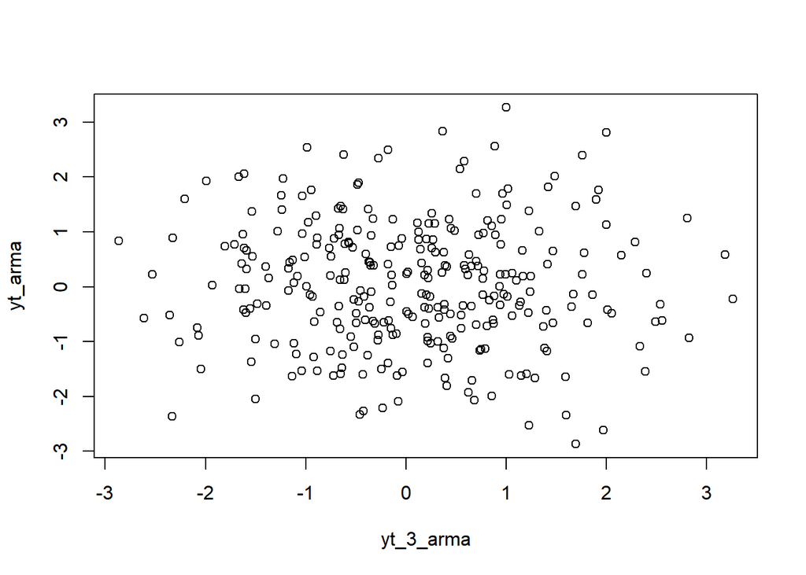

```r
plot(y=yt_arma,x=yt_3_arma)
```

```r
cor(yt_arma,yt_3_arma)
```

```
## [1] -0.03443694
```